# R: Clasificación con modelos Logit

Cristian Urbano

# 1 Librerías y Datos

Primero instalamos los paquetes necesarios para hacer una regresión logística.

```r
install.packages('ISLR','rms','margins','InformationValue') #Recuerde que esto solo se hace una vez
```

```r
library(ISLR)
library(dplyr)
library(rms)
library(margins)
library(InformationValue)
library(inspectdf)

options(scipen = 9999) #Para quitar la notación científica

datos <- Default

head(datos, 10)
```

```
##    default student   balance    income
## 1       No      No  729.5265 44361.625
## 2       No     Yes  817.1804 12106.135
## 3       No      No 1073.5492 31767.139
## 4       No      No  529.2506 35704.494
## 5       No      No  785.6559 38463.496
## 6       No     Yes  919.5885  7491.559
## 7       No      No  825.5133 24905.227
## 8       No     Yes  808.6675 17600.451
## 9       No      No 1161.0579 37468.529
## 10      No      No    0.0000 29275.268
```

```r
#Inspeccionamos la base de datos
inspeccion_na <- inspect_na(datos)
inspeccion_na
```

```
## # A tibble: 4 x 3
##   col_name   cnt  pcnt
##   <chr>    <int> <dbl>
## 1 default      0     0
## 2 student      0     0
## 3 balance      0     0
## 4 income       0     0
```

```r
#Generemos una columna ID
datos$id = c(1:nrow(datos))

#Cambiar la variable para que quede 0 y 1

datos$default_b <- recode(datos$default, 'Yes'=1, 'No'=0)
```

Miremos la variable de respuesta

```r
table(datos$default_b)
```

```
##
##    0    1
## 9667  333
```

Tenemos 333 personas que dejaron de pagar su deuda (cayeron en default).

# 2 Análisis de clasificación

## 2.1 División de la muestra

```r
#Dividir train y test
#Usar 70% del dataset para entrenamiento, el resto para evaluación

set.seed(1) #Poner la semilla para el generador de números aleatorios

train <- datos %>% sample_frac(0.70) #Dejar el 70% de los datos en el dataframe de entrenamiento
test  <- anti_join(datos, train, by = 'id') #El resto queda en el de test
```

## 2.2 Modelo

Corremos el modelo usando la función glm()

```r
#Regresión logística
modelo <- glm(default_b ~ student + balance ,
              family= binomial(link = 'logit'), data=train)

summary(modelo)
```

```
##
## Call:
## glm(formula = default_b ~ student + balance, family = binomial(link = "logit"),
##     data = train)
##
## Deviance Residuals:
##     Min       1Q   Median       3Q      Max
## -2.4261  -0.1377  -0.0542  -0.0203   3.4070
##
## Coefficients:
##                Estimate  Std. Error z value             Pr(>|z|)
## (Intercept) -10.7002171   0.4394509 -24.349 < 0.0000000000000002 ***
## studentYes   -0.8591128   0.1815058  -4.733           0.00000221 ***
## balance       0.0056835   0.0002739  20.748 < 0.0000000000000002 ***
## ---
## Signif. codes:  0 '***' 0.001 '**' 0.01 '*' 0.05 '.' 0.1 ' ' 1
##
## (Dispersion parameter for binomial family taken to be 1)
##
##     Null deviance: 2030.3  on 6999  degrees of freedom
## Residual deviance: 1073.9  on 6997  degrees of freedom
## AIC: 1079.9
##
## Number of Fisher Scoring iterations: 8
```

Observe que la tabla de resultados es muy parecida a una regresión lineal. Pero no se deje confundir, los betas nos tienen interpretación.

Probemos otros modelos, por ejemplo incluyendo todas las variables

```r
modelo2 <- lrm(default_b ~ student + balance + income, data=train)
print(modelo2)
```

```
## Logistic Regression Model
##
##  lrm(formula = default_b ~ student + balance + income, data = train)
##
##                          Model Likelihood      Discrimination    Rank Discrim.
##                                Ratio Test             Indexes          Indexes
##  Obs           7000    LR chi2     956.75      R2       0.507    C       0.955
##   0            6769    d.f.             3     R2(3,7000)0.127    Dxy     0.909
##   1             231    Pr(> chi2) <0.0001    R2(3,670.1)0.759    gamma   0.909
##  max |deriv| 0.0009                            Brier    0.021    tau-a   0.058
##
##              Coef     S.E.   Wald Z Pr(>|Z|)
##  Intercept   -10.9453 0.5880 -18.62 <0.0001
##  student=Yes  -0.7167 0.2886  -2.48 0.0130
##  balance       0.0057 0.0003  20.71 <0.0001
##  income        0.0000 0.0000   0.64 0.5240
##
```

Observe que los betas de student y el balance salen significativos, el de income no.

Mire lo que sucede si hacemos un modelo solo con income

```r
modelo3 <- lrm(default_b ~ income , data=train)
print(modelo3)
```

```
## Logistic Regression Model
##
##  lrm(formula = default_b ~ income, data = train)
##
##                        Model Likelihood      Discrimination    Rank Discrim.
##                              Ratio Test             Indexes          Indexes
##  Obs          7000    LR chi2      0.20      R2       0.000    C       0.510
##   0           6769    d.f.            1     R2(1,7000)0.000    Dxy     0.020
##   1            231    Pr(> chi2) 0.6552    R2(1,670.1)0.000    gamma   0.021
##  max |deriv| 3e-08                           Brier    0.032    tau-a   0.001
##
##            Coef    S.E.   Wald Z Pr(>|Z|)
##  Intercept -3.3032 0.1790 -18.45 <0.0001
##  income     0.0000 0.0000  -0.45 0.6553
##
```

Observe que es un mal modelo. Mire el pseudo R2.

Nos quedamos con el primer modelo que hicimos. Es importante hacer este paso de exploración de distintos modelos.

## 2.3 Interpretación

Calculamos los efectos marginales promedio

```r
efectos_marginales <- marginal_effects(modelo)

train_mfx <- cbind(train, efectos_marginales) #Unimos los efectos a la base de entrenamiento

train_mfx %>%
  dplyr::summarize(media_mfx_balance = mean(dydx_balance),
            media_mfx_studentYes = mean(dydx_studentYes))
```

```
##   media_mfx_balance media_mfx_studentYes
## 1      0.0001188668          -0.01693726
```

Observe que en promedio ser estudiante dimsinuye la probabilidad de caer en default. Un mayor balance de la deuda aumenta la probabilidad de default.

Una manera de visualizar los resultados es hacer un gráfico de puntos:

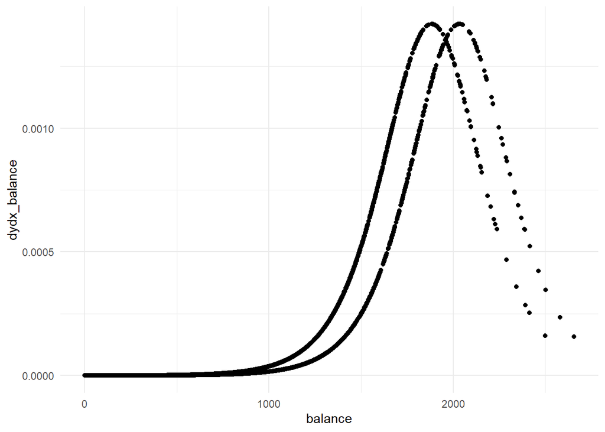

```r
ggplot(train_mfx, aes(y=dydx_balance, x=balance)) +
  geom_point() +
  theme_minimal()
```

Aquí podemos observar la no linealidad de los efectos. Recuerde que esto es un ejercicio con todas las demás variables constantes.

## 2.4 Evaluación

### 2.4.1 Muestra de entrenamiento

Para evaluar necesitamos primero predecir las probabilidades

```r
#Predecir la probabilidad de default
train_pred <-  data.frame('prob_default'=predict(modelo, type="response"))
train_pred <- cbind(train,train_pred) #unir la predicción a los datos originales

head(train_pred, 5)
```

```
##   default student   balance   income   id default_b prob_default
## 1      No      No  939.0985 45519.02 1017         0 0.0046654417
## 2      No     Yes  397.5425 22710.87 8004         0 0.0000914235
## 3     Yes      No 1511.6110 53506.94 4775         1 0.1082203441
## 4      No      No  301.3194 51539.95 9725         0 0.0001249236
## 5      No      No  878.4461 29561.78 8462         0 0.0033096050
```

Observe que hemos calculado la probabilidad de cada individuo (última columna).

Ahora podemos calcular las métricas

```r
#Calcular métricas en el área de entrenamiento
cm_train <- confusionMatrix(train_pred$default_b, train_pred$prob_default)
cm_train
```

```
##      0   1
## 0 6739 152
## 1   30  79
```

```r
accuracy_train <- (cm_train[1,1] + cm_train[2,2]) / nrow(train_pred)
sensibilidad_train <- sensitivity(train_pred$default_b, train_pred$prob_default)
especificidad_train <- specificity(train_pred$default_b, train_pred$prob_default)

cat(paste0("Accuracy: ", round(accuracy_train*100,1),
      "\nSensibilidad: ", round(sensibilidad_train*100,1),
      "\nEspecificidad: ", round(especificidad_train*100,1)))
```

```
## Accuracy: 97.4
## Sensibilidad: 34.2
## Especificidad: 99.6
```

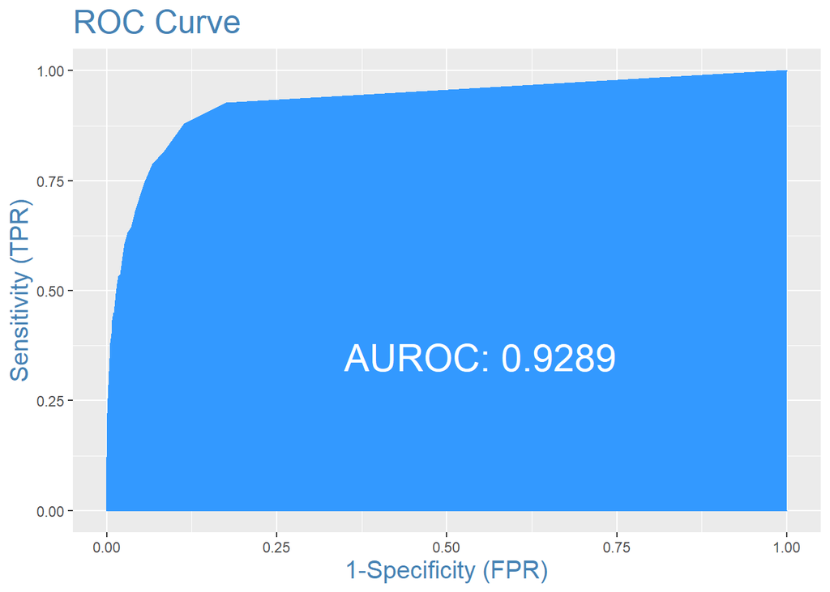

```r
plotROC(train_pred$default_b, train_pred$prob_default)
```

En general las métricas indican que el modelo está bien. Aunque no predice muy bien la categoría de interés, es decir que no puede clasificar correctamente a los que dejarán de pagar su deuda.

### 2.4.2 Muestra de evaluación

```r
#Predecir la probabilidad de default
test_pred <-  data.frame('prob_default'=predict(modelo, test ,type="response"))
test_pred <- cbind(test,test_pred)

#Calcular métricas en el área de evaluación
cm_test <- confusionMatrix(test_pred$default_b, test_pred$prob_default)
cm_test
```

```
##      0  1
## 0 2896 80
## 1    2 22
```

```r
accuracy_test <- (cm_test[1,1] + cm_test[2,2]) / nrow(train_pred)
sensibilidad_test <- sensitivity(test_pred$default_b, test_pred$prob_default)
especificidad_test <- specificity(test_pred$default_b, test_pred$prob_default)

cat(paste0("Accuracy: ", round(accuracy_train*100,1),
      "\nSensibilidad: ", round(sensibilidad_train*100,1),
      "\nEspecificidad: ", round(especificidad_train*100,1)))
```

```
## Accuracy: 97.4
## Sensibilidad: 34.2
## Especificidad: 99.6
```

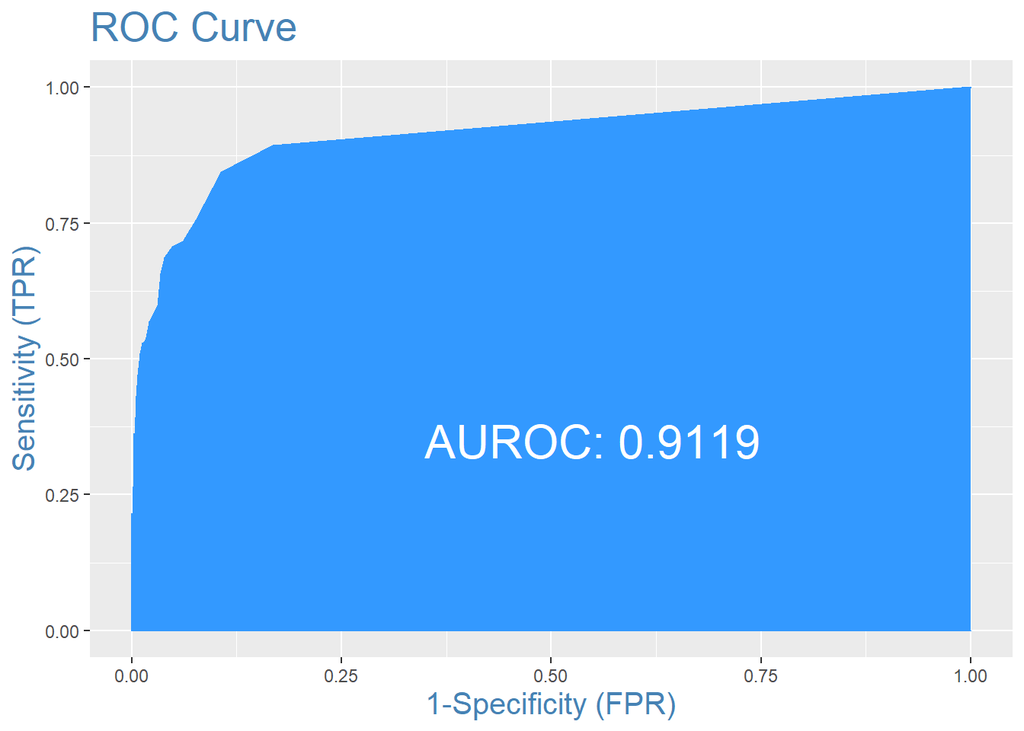

```r
plotROC(test_pred$default_b, test_pred$prob_default)
```

Además, la curva ROC nos sugiere que podemos jugar con el punto de corte para mejorar los resultados.

## 2.5 Punto de corte

Como vimos antes, el modelo no predice muy bien a los clientes que dejarán de pagar su deuda. Veamos como se comporta nuestra predicción con respecto a la realidad.

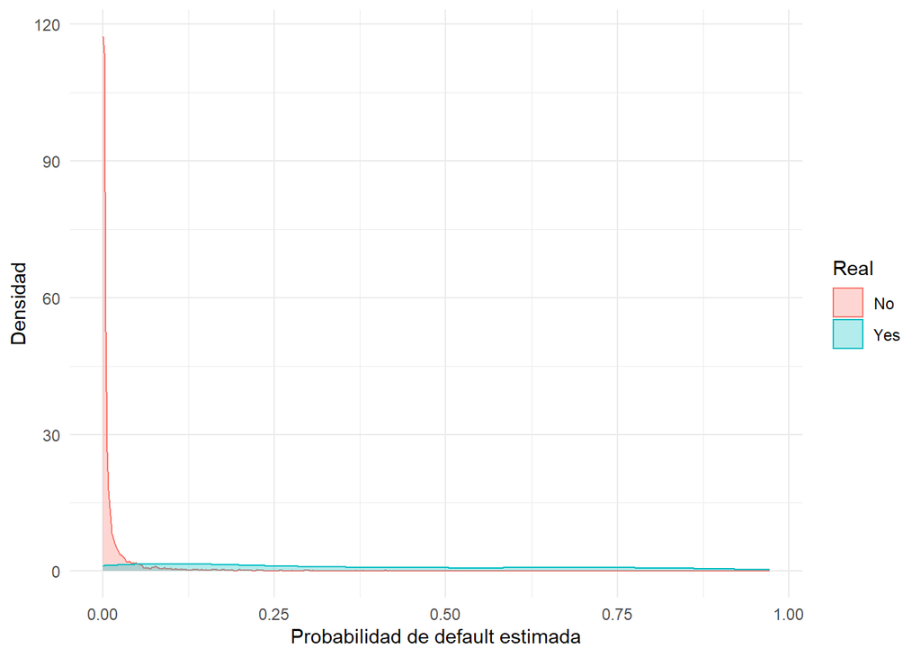

```r
ggplot(train_pred, aes(x=prob_default, fill=default, color=default)) +
  geom_density(alpha=0.3) +
  labs(x='Probabilidad de default estimada', y='Densidad', color='Real', fill='Real') +
  theme_minimal()
```

Con el análisis gráfico podemos ver que bajar el punto de corte puede ayudar a aumentar la sensibilidad, a costa de sacrificar poder de predicción para los que si pagarán (especificidad).

El punto de corte se puede cambiar desde las funciones confusionMatrix, sensitivity y specificity. Probemos a hacerlo en el área de entrenamiento. El argumento para cambiarlo es threshold.

```r
cm_train <- confusionMatrix(train_pred$default_b, train_pred$prob_default, threshold = 0.15)
cm_train
```

```
##      0   1
## 0 6504  79
## 1  265 152
```

```r
accuracy_train <- (cm_train[1,1] + cm_train[2,2]) / nrow(train_pred)
sensibilidad_train <- sensitivity(train_pred$default_b, train_pred$prob_default, threshold = 0.15)
especificidad_train <- specificity(train_pred$default_b, train_pred$prob_default, threshold = 0.15)

cat(paste0("Accuracy: ", round(accuracy_train*100,1),
      "\nSensibilidad: ", round(sensibilidad_train*100,1),
      "\nEspecificidad: ", round(especificidad_train*100,1)))
```

```
## Accuracy: 95.1
## Sensibilidad: 65.8
## Especificidad: 96.1
```

Por ejemplo, acá cambiamos el punto de corte a 0.15. Observe que la sensibilidad ha mejorado mucho a costa de perder solo un poco de especificidad. Este modelo parece ser mejor para tomar decisiones!

Veamos como se comporta sobre el área de evaluación

```r
#Calcular métricas en el área de evaluación
cm_test <- confusionMatrix(test_pred$default_b, test_pred$prob_default, threshold = 0.15)
cm_test
```

```
##      0  1
## 0 2804 38
## 1   94 64
```

```r
accuracy_test <- (cm_test[1,1] + cm_test[2,2]) / nrow(train_pred)
sensibilidad_test <- sensitivity(test_pred$default_b, test_pred$prob_default, threshold = 0.15)
especificidad_test <- specificity(test_pred$default_b, test_pred$prob_default, threshold = 0.15)

cat(paste0("Accuracy: ", round(accuracy_train*100,1),
      "\nSensibilidad: ", round(sensibilidad_train*100,1),
      "\nEspecificidad: ", round(especificidad_train*100,1)))
```

```
## Accuracy: 95.1
## Sensibilidad: 65.8
## Especificidad: 96.1
```

Las métricas son similares. Así que hemos mejorado el modelo solo modificando el punto de corte, y sigue siendo estable!